# Coral-Tissue-Analysis

Meron G. Tekle

2024-06-04

# Analysis codes for Coral Tissue samples

## Load required packages for the analysis

```r
library(tidyverse)
library(qiime2R)
library(microbiome)
library(phyloseq)
library(stringr)
library(forcats)
library(reshape2)
```

```r
library(ggraph)
library(igraph)
library(tidygraph)
library(ggalt)
library(vegan)
library(ggsci)
library(patchwork)
library(purrr)
library(scales)
library(cowplot)
library(pander)
```

## Import .qza files from qiime2 into R using the qiime2R package and create a phyloseq object

```r
physeq <- qza_to_phyloseq(
  features = "../qiime2_output/table.qza",
  tree = "../qiime2_output/rooted_tree.qza",
  "../qiime2_output/blast-taxonomy-results-99.qza",
  metadata = "../qiime2_output/sample-metadata.txt")
```

### use the microbiome package to create tible files for feature table and taxonomy table which will be merged later to make analysis easier down the road

```r
otu.tib <- otu_tibble(physeq, column.id = "FeatureID")  #retrieves our feature table
tax.tib <- tax_tibble(physeq, column.id = "FeatureID") #retrieves our taxonomic assignment table
sample_tib <- sample_tibble(physeq, column.id = "SampleID") #retrieves or sample metadata
```

### Then we will merge all these tables using shared columns such as “SampleID” and “featureID”

```r
dat <- otu.tib %>%
  pivot_longer(-FeatureID, names_to = "SampleID", values_to = "count") #creates a file with the columns FeatureID(ASV id given by qiime), SampleID (Sample names) and Count(abundance of a feature per sample). Now it is easier to join with other tables
```

### Use left_join to add taxa table, metadata

```r
dat <- dat %>%
  left_join(tax.tib, by="FeatureID")

dat <- dat %>%
  left_join(sample_tib, by = "SampleID")

#dat
```

### Now to we add shannon index and PCoA results to the data table, but first we import both shannon and PCoA results

```r
shannon <- read_qza("../qiime2_output/shannon_vector.qza") #import from qiime using qiime2R

shannon <- shannon$data %>% rownames_to_column("SampleID") #make it easier to merge to "dat" using "SampleID"

dat <- dat %>%
  left_join(shannon, by = "SampleID")

#dat
```

### We also add a column for observed features

```r
obs_feat <- read_qza("../qiime2_output/observed_features_vector.qza") #import from qiime using qiime2R
```

```r
obs_feat <- obs_feat$data %>% rownames_to_column("SampleID") #make it easier to merge to "dat" using "SampleID"

dat <- dat %>%
  left_join(obs_feat, by = "SampleID")
```

### Now we do the same with PCoA results

```r
uwunifrac<-read_qza("../qiime2_output/unweighted_unifrac_pcoa_results.qza") #import unweighted unifrac results from qiime2

unifrac_modify<- uwunifrac$data$Vectors %>%
  select(SampleID, PC1, PC2)  #we select only two dimensions because we cannot effectively show more dimension on paper

dat <- dat %>%
  left_join(unifrac_modify, by = "SampleID")

#dat
```

```r
#create a depth category
dat <- dat %>%
  mutate(depth2= case_when(Depth <= 3 ~ "Shallow (1-3m)",
                           Depth >= 4 & Depth <= 10 ~ "Deeper Shallow (4-10m)",
                           Depth >= 11 & Depth <= 29 ~ "Intermediate (11-29m)",
                           Depth >= 30 & Depth <= 50 ~ "Upper Mesophotic (30-50m)",
                           Depth >= 51 & Depth <= 70 ~ "Middle Mesophotic (51-70m)",
                           Depth >70 ~ "Lower Mesophotic (>70)"))

#order the categories based on depth
dat$depth2 <- factor(dat$depth2,
                              levels = c("Shallow (1-3m)",
                                         "Deeper Shallow (4-10m)",
                                         "Intermediate (11-29m)", "Upper Mesophotic (30-50m)",
                                         "Middle Mesophotic (51-70m)",
                                         "Lower Mesophotic (>70)"))
```

### Now we remove the accession numbers from our Species names and rename them as ITS2types

```r
dat <- dat %>%
  mutate(ITS2_types= (str_replace_all(pattern = '-.*', replacement = "", Species.x)))
```

# Part II - Analysis - visulaize alpha and beta diversity

### Now we begin analysis, but before we create plots, lets create a custom theme. This will make our code cleaner

```r
my_theme_alpha <-  theme(panel.border = element_rect(colour = "black", fill = NA),
                     panel.background = element_blank(),
                     panel.grid = element_blank(),
                     axis.text  = element_text(size = 10),
                     axis.text.x = element_text(angle = 0, face = "italic"),
                     axis.title = element_text(size = 20),
                     strip.background = element_blank(),
                     strip.text = element_text(size = 10),
                     axis.line.x = element_line(size = 0.5),
                     axis.line.y = element_line(size = 0.5),
                     legend.position = "right",
                     legend.text =element_text(size =6))
```

## Create a Shannon diversity Box Plot

### But before lets create a dataframe with each sample coressponding to a unique sahnnon diversity value

```r
dat_shannon <- dat %>%
  group_by(SampleID, Type, Depth, Genus.y, depth2) %>%
  summarise(Richness = unique(shannon_entropy))
```

```
## can override using the `.groups` argument.
```

```r
#dat_shannon
```

## Before ploting lets select well represented coral genera and remove genera with one observation

```r
dat_shannon <- droplevels(dat_shannon[dat_shannon$Genus.y == "Acropora"|dat_shannon$Genus.y == "Alveopora"|
                                   dat_shannon$Genus.y == "Galaxea"|dat_shannon$Genus.y == "Leptoseris"|
                                   dat_shannon$Genus.y == "Montipora"|dat_shannon$Genus.y == "Pocillopora",])

dat_shannon <- dat_shannon %>%
  group_by(SampleID, Type, Depth, Genus.y, depth2) %>%
  summarise(Richness = unique(Richness))
```

```
## can override using the `.groups` argument.
```

```r
#dat_shannon
```

### Now lets plot it

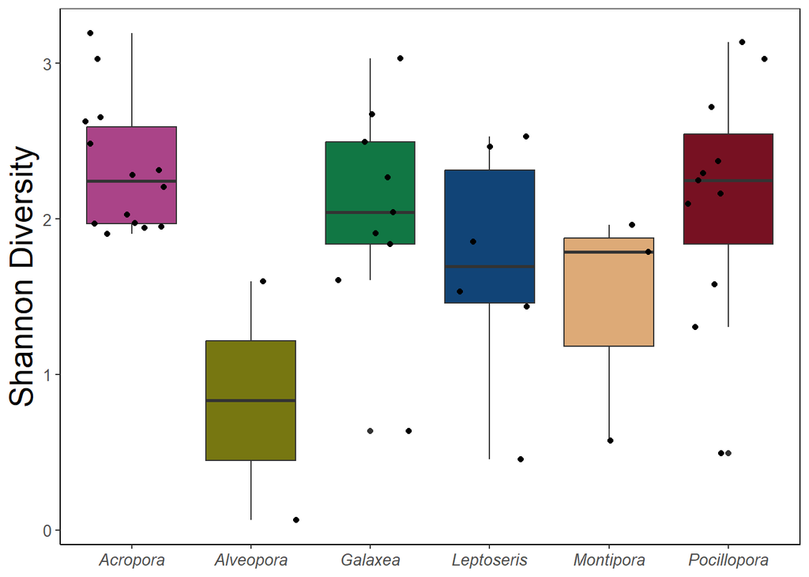

```r
fig7a <-dat_shannon %>%
  drop_na() %>%
  filter(Type != "Planula",) %>%#removes values from samples not included in analysis because of sampling depth
  ggplot(aes(Genus.y, Richness)) +
  geom_boxplot(aes(fill = Genus.y),position = "dodge", show.legend = F)+
  geom_jitter()+
  xlab(NULL)+
  ylab("Shannon Diversity")+
  scale_fill_manual(values = c("#AA4488","#777711","#117744",
                               "#114477","#DDAA77","#771122"))+
  my_theme_alpha

fig7a
```

```r
#fig7a <- ggsave("../figures/fig7a.png", height = 4, width = 5, device= "png")
```

## Plot shannon box for Acropora and Galaxea across depth

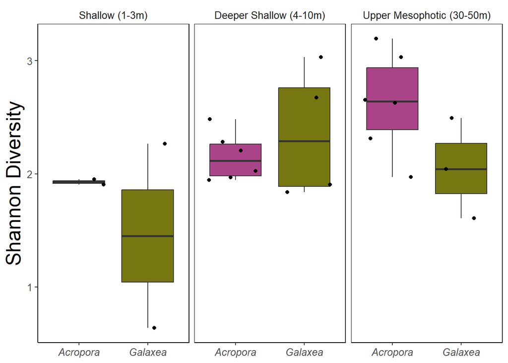

```r
fig7c <-dat_shannon %>%
  drop_na() %>%
  filter(Type != "Planula", Genus.y == "Acropora"| Genus.y == "Galaxea",) %>%   #removes values from samples not included in analysis because of sampling depth
  ggplot(aes(Genus.y, Richness)) +
  geom_boxplot(aes(fill = Genus.y),position = "dodge", show.legend = F)+
  geom_jitter()+
  facet_wrap(~depth2, scales = "free_x")+
  xlab(NULL)+
  ylab("Shannon Diversity")+
  scale_fill_manual(values = c("#AA4488","#777711","#117744",
                               "#114477","#DDAA77","#771122"))+
  my_theme_alpha

fig7c
```

```r
#fig7c <- ggsave("../figures/fig8.png", height = 4, width = 5, device= "png")
```

### create a custom theme for the plot

```r
my_theme_obs <-  theme(panel.border = element_rect(colour = "black", fill = NA),
                     panel.background = element_blank(),
                     panel.grid = element_blank(),
                     axis.text  = element_text(size = 8),
                     axis.text.x = element_text(angle = 90, face = "italic"),
                     axis.title = element_text(size = 20),
                     strip.background = element_blank(),
                     strip.text = element_text(size = 10),
                     axis.line.x = element_line(size = 0.5),
                     axis.line.y = element_line(size = 0.5),
                     legend.position = "right",
                     legend.text =element_text(size =6))
```

### Then group, order and plot

```r
dat_obs_feat <- dat %>%
  group_by(SampleID, Type, Depth, Genus.y, depth2) %>%
  summarise(observed_features = unique(observed_features))
```

```
## can override using the `.groups` argument.
```

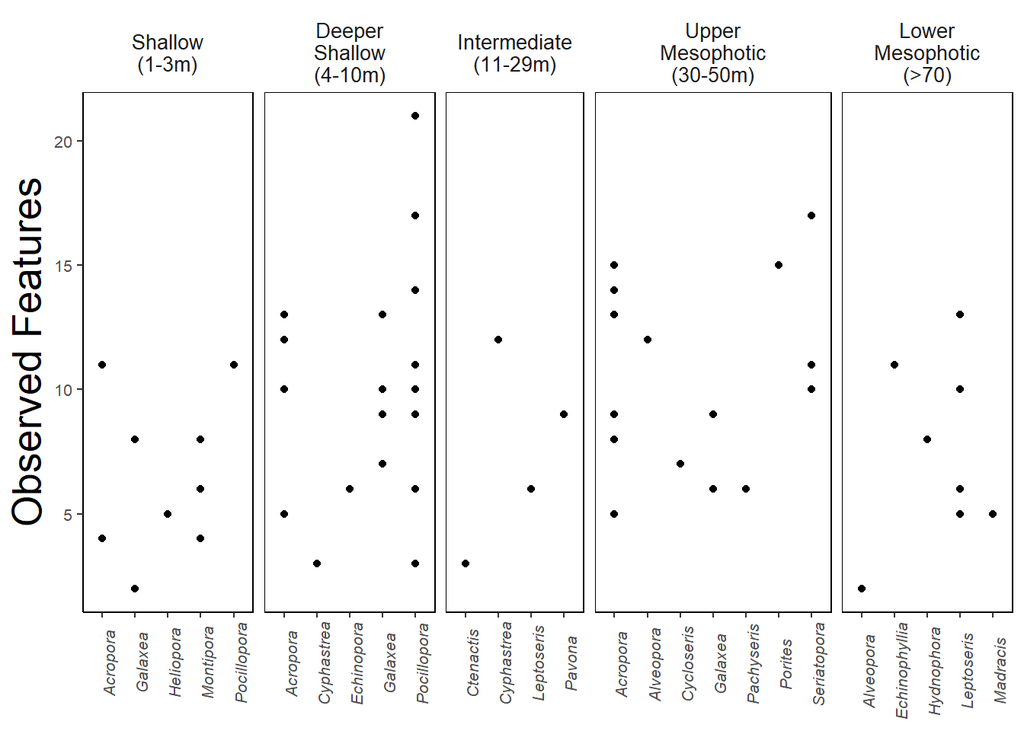

```r
fig7b <- dat_obs_feat %>%
  filter(!Type == "Planula") %>%
  drop_na() %>%
  ggplot(aes(Genus.y, observed_features)) +
  geom_point()+
  xlab(NULL)+
  ylab("Observed Features")+
  facet_grid(~depth2, scales = "free_x", space = "free_x",
             labeller = label_wrap_gen(width = 10))+
  my_theme_obs

fig7b
```

```r
#fig7b <- ggsave("../figures/fig7b.png", height = 4, width = 5, device= "png")
```

## Merge alpha diversity plots

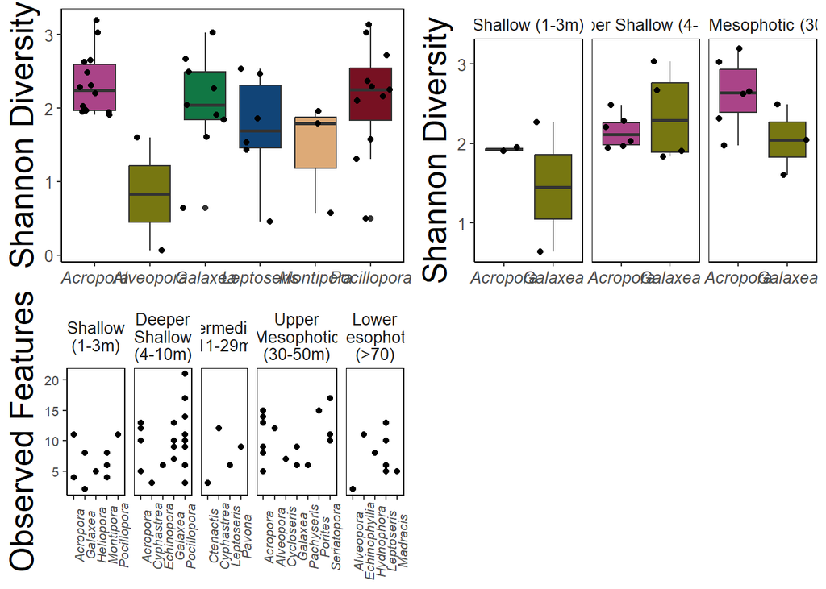

```r
fig7 <- plot_grid(fig7a, fig7c, fig7b, nrow = 2, rel_heights = 6, rel_widths = 4)

#fig7 <- ggsave("../figures/fig7.png", height = 7, width = 10, device= "png")

fig7
```

# Beta Diversity Plots

### create a custom theme

```r
my_theme_beta <-  theme(panel.border = element_rect(colour = "black", fill = NA),
                     panel.background = element_blank(),
                     panel.grid = element_blank(),
                     axis.text  = element_text(size = 8),
                     axis.text.x = element_text(angle = 90, face = "italic"),
                     axis.title = element_text(size = 20),
                     strip.background = element_blank(),
                     strip.text = element_text(size = 10),
                     axis.line.x = element_line(size = 0.5),
                     axis.line.y = element_line(size = 0.5),
                     legend.position = "right",
                     legend.text =element_text(size = 4))
```

## Create a PCoA ordination based on unweighted unifrac distances

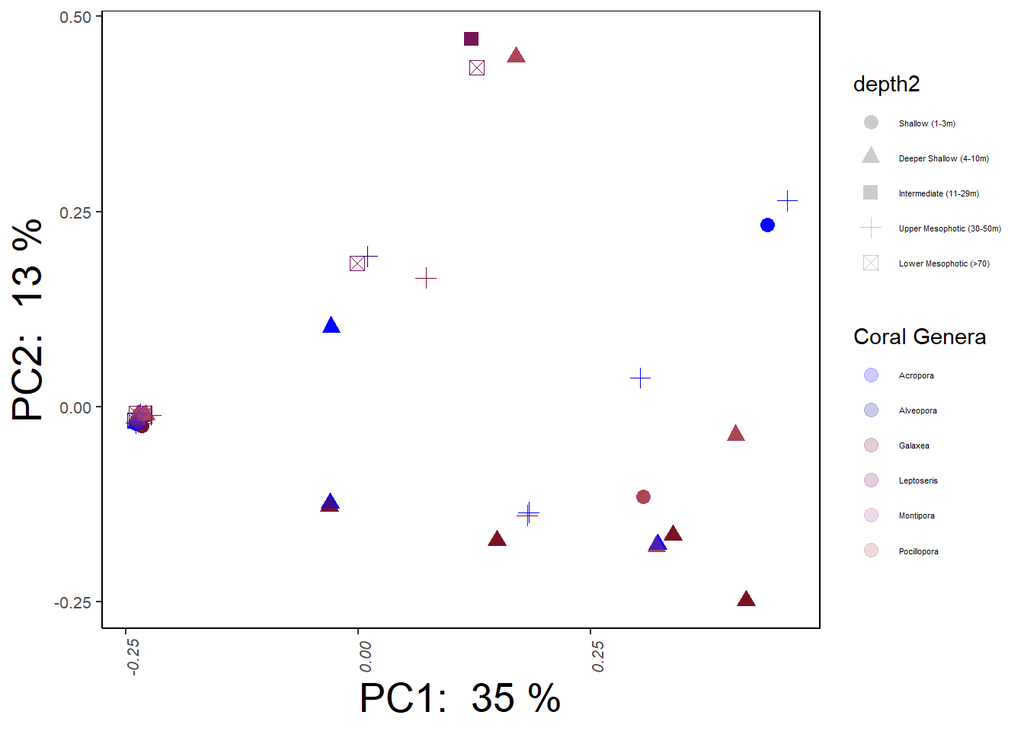

```r
dat_pcoa <- dat %>%
  group_by(SampleID, PC1 , PC2, Depth, Genus.y, depth2)

dat_pcoa <- droplevels(dat_pcoa[dat_pcoa$Genus.y == "Acropora"| dat_pcoa$Genus.y == "Alveopora"| dat_pcoa$Genus.y == "Galaxea"| dat_pcoa$Genus.y == "Leptoseris"| dat_pcoa$Genus.y == "Montipora"| dat_pcoa$Genus.y == "Pocillopora",])

fig8 <- dat_pcoa %>%
  filter(!Type == "Planula", ) %>%
  drop_na() %>% #drops na values
  ggplot(aes(x=PC1, y=PC2, color= Genus.y, shape = depth2))+
  geom_point(alpha=0.2, size = 3) +
  xlab(paste("PC1: ", round(100*uwunifrac$data$ProportionExplained[1]), "%")) +
  ylab(paste("PC2: ", round(100*uwunifrac$data$ProportionExplained[2]), "%"))+
  scale_color_manual(values= c("#0000FF","#00008F","#771122","#771155","#AA4488",
                              "#AA4455","#DD7788","#114477","#4477AA","#77AADD",
                              "#117777","#44AAAA","#117744","#44AA77","#88CCAA",
                              "#77CCCC","#777711","#AAAA44","#AA7744","#DDAA77",
                              "#774411","black","red"), name = "Coral Genera")+
  scale_x_continuous()+
  scale_shape_discrete()+
  my_theme_beta

fig8
```

```r
#fig8 <- ggsave("../figures/fig8.png", height = 4, width = 5, device= "png")
```

# Species Composition plot

## create a theme for the composition plot

```r
my_theme_bar <-  theme(panel.border = element_rect(colour = "black", fill = NA),
                     panel.background = element_blank(),
                     panel.grid = element_blank(),
                     axis.text  = element_text(size = 6),
                     axis.text.x = element_text(angle = 90, face = "italic"),
                     axis.text.x.top = element_text(size=8),
                     axis.title = element_text(size = 12),
                     strip.background = element_blank(),
                     strip.text = element_text(size = 8),
                     axis.line.x = element_line(size = 0.5),
                     axis.line.y = element_line(size = 0.5),
                     legend.position = "right",
                     legend.title = element_text(size = 8),
                     legend.key.size = unit(0.10, "cm"),
                     legend.text =element_text(size =8, face = "italic"))
```

### another theme for the galaxea and acropora stacked bar plots

```r
my_theme_bar_1 <-  theme(panel.border = element_rect(colour = "black", fill = NA),
                     panel.background = element_blank(),
                     panel.grid = element_blank(),
                     #axis.text  = element_text(size = 6),
                     #axis.text.x = element_text(angle = 0, face = "italic"),
                     axis.text.x.top = element_text(size=8),
                     axis.title = element_text(size = 12),
                     strip.background = element_blank(),
                     strip.text = element_text(size = 8),
                     axis.line.x = element_line(size = 0.5),
                     axis.line.y = element_line(size = 0.5),
                     legend.position = "bottom",
                     legend.title = element_text(size = 8),
                     legend.key.size = unit(0.10, "cm"),
                     legend.text =element_text(size =8, face = "italic"))
```

## Create a composition plot by genus

### Then summurize the top 24 ITS2 sequences

```r
total_top_counts <- dat %>% #summarize and arrange the total count of each genus across all samples
  group_by(ITS2_types) %>%
  summarize(total_top_counts = sum(count)) %>%
  arrange(desc(total_top_counts))

top_24_species <- total_top_counts %>% #get the 10 most abundant genus by count
  top_n(24,wt=total_top_counts) %>%
  pull(ITS2_types)

filtered_bar_dat <- dat %>% #filter the data to get the 10 most abundant genera
  filter(ITS2_types %in% top_24_species)

filtered_bar_dat<- filtered_bar_dat %>%
  group_by(ITS2_types) %>%
  mutate(proportion = count / sum(count))

filtered_bar_dat
```

```
## # A tibble: 24,274 × 29
## # Groups:   ITS2_types [24]
##    FeatureID  SampleID count Kingdom Phylum Class Order Family Genus.x Species.x
##    <chr>      <chr>    <dbl> <chr>   <chr>  <chr> <chr> <chr>  <chr>   <chr>
##  1 a78248289… Ate2         0 Unassi… <NA>   <NA>  <NA>  <NA>   <NA>    <NA>
##  2 a78248289… C12          0 Unassi… <NA>   <NA>  <NA>  <NA>   <NA>    <NA>
##  3 a78248289… C3           0 Unassi… <NA>   <NA>  <NA>  <NA>   <NA>    <NA>
##  4 a78248289… C6           0 Unassi… <NA>   <NA>  <NA>  <NA>   <NA>    <NA>
##  5 a78248289… CT2          0 Unassi… <NA>   <NA>  <NA>  <NA>   <NA>    <NA>
##  6 a78248289… I3           0 Unassi… <NA>   <NA>  <NA>  <NA>   <NA>    <NA>
##  7 a78248289… I4           0 Unassi… <NA>   <NA>  <NA>  <NA>   <NA>    <NA>
##  8 a78248289… Ihe2         0 Unassi… <NA>   <NA>  <NA>  <NA>   <NA>    <NA>
##  9 a78248289… Ihe3         0 Unassi… <NA>   <NA>  <NA>  <NA>   <NA>    <NA>
## 10 a78248289… Ihe4         0 Unassi… <NA>   <NA>  <NA>  <NA>   <NA>    <NA>
## # ℹ 24,264 more rows
## # ℹ 19 more variables: index1 <fct>, index2 <fct>, Sample_Project <fct>,
## #   Type <fct>, Depth <dbl>, Location <fct>, Reproduction <fct>, Island <fct>,
## #   Region <fct>, Genus.y <fct>, Species.y <fct>, Year <dbl>,
## #   shannon_entropy <dbl>, observed_features <int>, PC1 <dbl>, PC2 <dbl>,
## #   depth2 <fct>, ITS2_types <chr>, proportion <dbl>
```

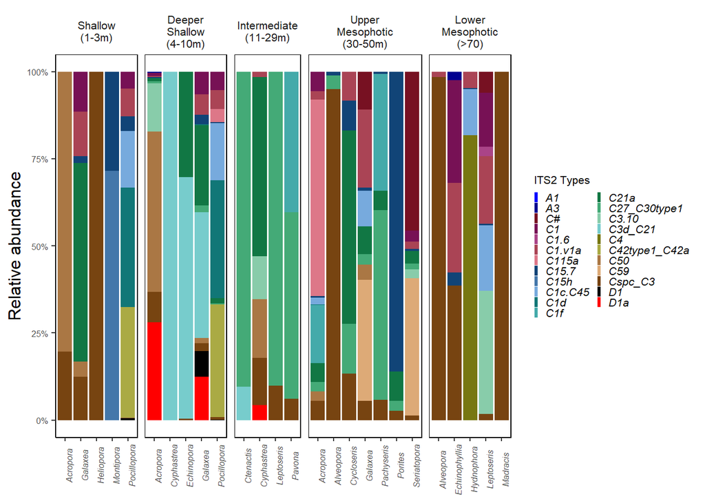

```r
figure5a <- filtered_bar_dat %>%
  drop_na() %>%
  filter(Type != "Planula") %>%
  ggplot(aes(Genus.y, proportion)) +
  facet_grid(~depth2 , scales = "free_x", space = "free_x", labeller = label_wrap_gen(width = 10))+
  geom_bar(aes (fill= ITS2_types), stat = "identity", position = "fill", width = 0.9)+
  scale_fill_discrete(name = NULL)+
  scale_fill_manual(values= c("#0000FF","#00008F","#771122","#771155","#AA4488",
                              "#AA4455","#DD7788","#114477","#4477AA","#77AADD",
                              "#117777","#44AAAA","#117744","#44AA77","#88CCAA",
                              "#77CCCC","#777711","#AAAA44","#AA7744","#DDAA77",
                              "#774411","black","red"), name = "ITS2 Types" )+
  scale_y_continuous(name = "Relative abundance",
                     labels = scales::percent) +
  labs(x = NULL)+
  scale_x_discrete(labels = function(x) str_wrap(x, width = 6))+
  my_theme_bar
figure5a
```

```r
#figure5a <- ggsave("../figures/figure5a.png", height = 5, width = 10, device= "png")
```

## Complement figure 5a by adding stacked bar plots of individual depth generalist corals (Galaxea and Acropora)

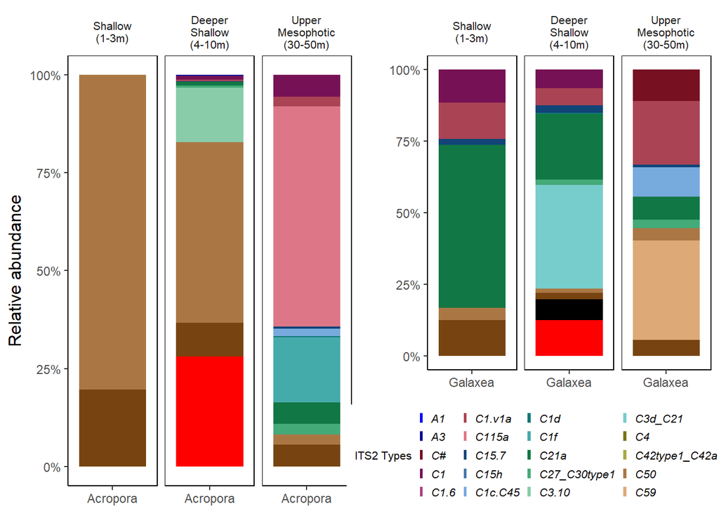

```r
figure5b <- filtered_bar_dat %>%
  drop_na() %>%
  filter(Genus.y == "Acropora", Type != "Planula") %>%
  ggplot(aes(Genus.y, proportion)) +
  facet_grid(~depth2 , scales = "free_x", space = "free_x", labeller = label_wrap_gen(width = 10))+
  geom_bar(aes (fill= ITS2_types), stat = "identity", position = "fill", width = 0.9, show.legend = F)+
  scale_fill_discrete(name = NULL)+
  scale_fill_manual(values= c("#0000FF","#00008F","#771122","#771155","#AA4488",
                              "#AA4455","#DD7788","#114477","#4477AA","#77AADD",
                              "#117777","#44AAAA","#117744","#44AA77","#88CCAA",
                              "#77CCCC","#777711","#AAAA44","#AA7744","#DDAA77",
                              "#774411","black","red"), name = "ITS2 Types" )+
  scale_y_continuous(name = "Relative abundance",
                     labels = scales::percent) +
  labs(x = NULL)+
  scale_x_discrete(labels = function(x) str_wrap(x, width = 6))+
  my_theme_bar_1
figure5c <- filtered_bar_dat %>%
  drop_na() %>%
  filter(Genus.y == "Galaxea",) %>%
  ggplot(aes(Genus.y, proportion)) +
  facet_grid(~depth2 , scales = "free_x", space = "free_x", labeller = label_wrap_gen(width = 10))+
  geom_bar(aes (fill= ITS2_types), stat = "identity", position = "fill", width = 0.9)+
  scale_fill_discrete(name = NULL)+
  scale_fill_manual(values= c("#0000FF","#00008F","#771122","#771155","#AA4488",
                              "#AA4455","#DD7788","#114477","#4477AA","#77AADD",
                              "#117777","#44AAAA","#117744","#44AA77","#88CCAA",
                              "#77CCCC","#777711","#AAAA44","#AA7744","#DDAA77",
                              "#774411","black","red"), name = "ITS2 Types" )+
  scale_y_continuous(name = " ",
                     labels = scales::percent) +
  labs(x = NULL)+
  scale_x_discrete(labels = function(x) str_wrap(x, width = 6))+
  my_theme_bar_1
figure5 <- plot_grid(figure5b, figure5c, rel_widths = 5, rel_heights = 10)

figure5
```

```r
#figure5 <- ggsave("../figures/figure5.png", height = 5, width = 10, device= "png")
```

## Bar plot for only A.tenuis samples to compare between Planula and Adult samples

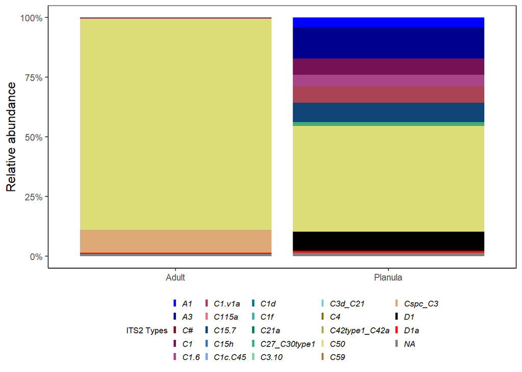

```r
Figure6a <- filtered_bar_dat %>%
  select(SampleID, Type, Species.y, ITS2_types, count) %>%
  filter(Species.y == "Acropora tenuis") %>%
  as.data.frame() %>%
  ggplot(aes(Type, count))+
  geom_bar(aes (fill= ITS2_types), stat = "identity", position = "fill", width = 0.9)+
  scale_fill_discrete(name = NULL)+
  scale_fill_manual(values= c("#0000FF","#00008F","#771122","#771155",
                              "#AA4488","#AA4455","#DD7788","#114477","#4477AA",
                              "#77AADD","#117777","#44AAAA","#117744","#44AA77",
                              "#88CCAA","#77CCCC","#777711","#AAAA44","#DDDD77",
                              "#AA7744","#DDAA77","black", "red"), name = "ITS2 Types" )+
  scale_y_continuous(name = "Relative abundance",
                     labels = scales::percent) +
  labs(x = NULL)+
  my_theme_bar_1
Figure6a
```

```r
#ggsave("../figures/figure6a.png", height = 4, width = 5, device= "png")
```

## Create a pichart showing compositon by coral genera

### lets create a custom theme for this plot too.

```r
my_theme_pie <-  theme(panel.border = element_rect(colour = "black", fill = NA),
                     #panel.background = element_blank(),
                     #panel.grid = element_blank(),
                     #axis.text  = element_text(size = 8),
                     #axis.text.x = element_text(angle = 90, face = "italic"),
                     #axis.text.x.top = element_text(size=8),
                     #axis.title = element_text(size = 16),
                     strip.background = element_blank(),
                     strip.text = element_text(size = 8),
                     axis.line.x = element_line(size = 0.5),
                     axis.line.y = element_line(size = 0.5),
                     legend.position = "right",
                     legend.title = element_text(size = 10),
                     legend.key.size = unit(0.25, "cm"),
                     legend.text =element_text(size =8, face = "italic"))
```

```r
figure6x <- filtered_bar_dat %>%
  filter(! Type== "Planula") %>%
  ggplot(aes("", count, fill = ITS2_types )) +
  geom_bar(stat = "identity", position = "fill", width = 1)+
  coord_polar("y", start = 0)+
 scale_fill_manual(values= c("#0000FF","#00008F","#771122","#771155",
                              "#AA4488","#AA4455","#DD7788","#114477","#4477AA",
                              "#77AADD","#117777","#44AAAA","#117744","#44AA77",
                              "#88CCAA","#77CCCC","#777711","#AAAA44","#DDDD77",
                              "#AA7744","#DDAA77","black", "red"), name = "ITS2 Types" )+
  scale_y_continuous(name = "Relative abundance",
                     labels = scales::percent) +
  facet_wrap(~Genus.y, labeller=labeller(Genus.y = label_wrap_gen(width = 12)))+
  my_theme_pie +
  theme_void()+
  theme(legend.title = element_text(size = 8),
        legend.text =element_text(size =8, face = "italic"),
        legend.key.size = unit(0.25, "cm"))


figure6x <- ggsave("../figures/fig6x.png", height = 5, width = 10, device= "png")
```

[figure not shown]

```r
figure6b  <- filtered_bar_dat %>%
  select(SampleID, Type, Species.y, ITS2_types, count) %>%
  filter(Species.y == "Acropora tenuis") %>%
  ggplot(aes("", count, fill = ITS2_types )) +
  geom_bar(stat = "identity", position = "fill", width = 1, show.legend = F)+
  coord_polar("y", start = 0)+
 scale_fill_manual(values= c("#0000FF","#00008F","#771122","#771155",
                              "#AA4488","#AA4455","#DD7788","#114477","#4477AA",
                              "#77AADD","#117777","#44AAAA","#117744","#44AA77",
                              "#88CCAA","#77CCCC","#777711","#AAAA44","#DDDD77",
                              "#AA7744","#DDAA77","black", "red"), name = "ITS2 Types" )+
  scale_y_continuous(name = "Relative abundance",
                     labels = scales::percent) +
  facet_wrap(~Type, labeller=labeller(Genus.y = label_wrap_gen(width = 12)))+
  my_theme_pie +
  theme_void()+
  theme(legend.position = "none")

figure6b
```

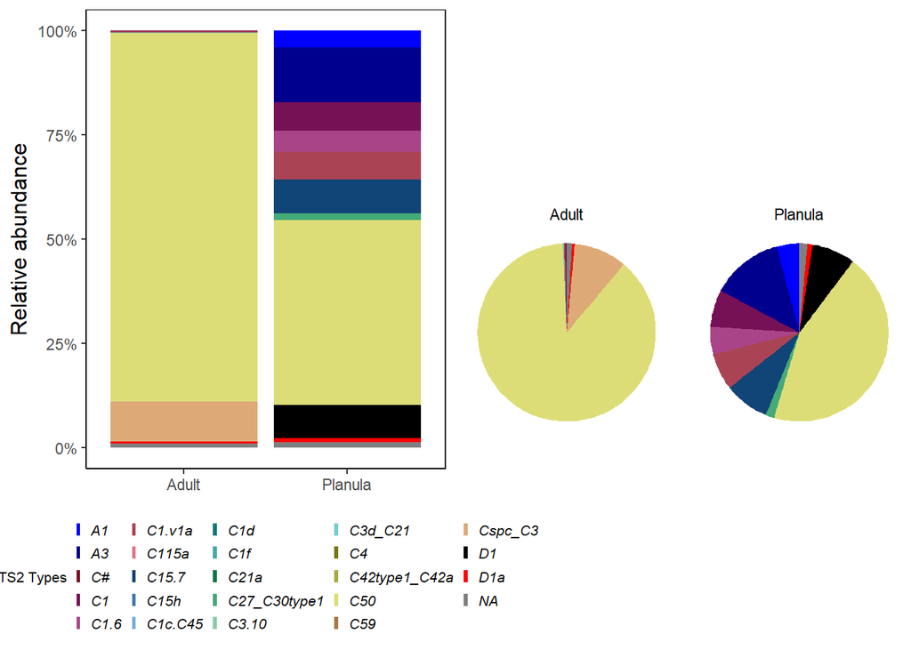

```r
## Combine figure b
figure6 <- plot_grid(Figure6a, figure6b, rel_widths = 5, rel_heights = 10)

figure6
```

```r
#ggsave("../figures/figure6.png", device= "png")
```

# Summary Analysis

## Counting the most abundant ITSTypes

```r
ITS2_sum_by_species <- dat %>% select(FeatureID, SampleID, count, ITS2_types) %>%
  group_by(ITS2_types) %>%
  summarize(species_count = sum(count)) %>%
  mutate(species_percent = species_count/sum(species_count) * 100)

ITS2_sum_by_species
```

```
## # A tibble: 61 × 3
##    ITS2_types         species_count species_percent
##    <chr>                      <dbl>           <dbl>
##  1 A1                          1998         1.36
##  2 A2                             2         0.00136
##  3 A3                          2658         1.80
##  4 A6                           119         0.0807
##  5 Azadinium spinosum             2         0.00136
##  6 C#                           405         0.275
##  7 C1                          4178         2.83
##  8 C1#                           11         0.00746
##  9 C1.6                        1051         0.713
## 10 C1.v1a                     19542        13.3
## # ℹ 51 more rows
```

## finding core taxa, ITS2 genotype present in all samples of corals

```r
ps_core <- core_members(physeq, detection = 0.01, prevalence = 0.5)

ps_core
```

```
## [1] "4d0116bd2ae4547f8b14b94a824e2d2e"
```

```r
##No core taxa found in all corals but C3 is present in half of all corals
```

# Multivariate test analysis using the phyloseq object

## PERMANOVA and betadisper on unweighted unifrac distance

### check for significance by depoth and genus

```r
uwuni <- phyloseq::distance(physeq, method = "unifrac", weighted = FALSE)  #unweighted unifrac

sampleddf <- data.frame(sample_data(physeq))

adonis2(formula = uwuni ~ Depth + Genus, data = sampleddf)
```

```
## Permutation test for adonis under reduced model
## Terms added sequentially (first to last)
## Permutation: free
## Number of permutations: 999
##
## adonis2(formula = uwuni ~ Depth + Genus, data = sampleddf)
##           Df SumOfSqs      R2      F Pr(>F)
## Depth      1   0.9451 0.04596 5.3845  0.001 ***
## Genus     21   5.0481 0.24550 1.3695  0.020 *
## Residual  83  14.5688 0.70853
## Total    105  20.5620 1.00000
## ---
## Signif. codes:  0 '***' 0.001 '**' 0.01 '*' 0.05 '.' 0.1 ' ' 1
```

##both are significant test for dispersion

```r
betatype <- betadisper(uwuni, sampleddf$Type) #check for sample Type
anova(betatype)
```

```
## Analysis of Variance Table
##
## Response: Distances
##            Df Sum Sq  Mean Sq F value Pr(>F)
## Groups      1 0.0264 0.026419  0.4751 0.4922
## Residuals 104 5.7829 0.055604
```

```r
betagenus <- betadisper(uwuni, sampleddf$Genus)
anova(betagenus)
```

```
## Analysis of Variance Table
##
## Response: Distances
##           Df Sum Sq  Mean Sq F value   Pr(>F)
## Groups    21 1.9333 0.092061   2.377 0.002839 **
## Residuals 84 3.2533 0.038730
## ---
## Signif. codes:  0 '***' 0.001 '**' 0.01 '*' 0.05 '.' 0.1 ' ' 1
```

```r
TukeyHSD(betagenus)
```

```
##   Tukey multiple comparisons of means
##     95% family-wise confidence level
##
## Fit: aov(formula = distances ~ group, data = df)
##
## $group
##                                      diff        lwr        upr     p adj
## Alveopora-Acropora          -6.482830e-02 -0.5973892 0.46773255 1.0000000
## Bernardpora-Acropora        -3.776454e-01 -1.1196417 0.36435096 0.9507861
## cf. Madracis-Acropora       -3.776454e-01 -1.1196417 0.36435096 0.9507861
## Ctenactis-Acropora          -3.776454e-01 -1.1196417 0.36435096 0.9507861
## Cycloseris-Acropora         -3.776454e-01 -1.1196417 0.36435096 0.9507861
## Cyphastrea-Acropora          2.604018e-02 -0.5065207 0.55860103 1.0000000
## Dendrophyllid-Acropora      -3.776454e-01 -1.1196417 0.36435096 0.9507861
## Echinophyllia-Acropora       9.104631e-02 -0.3501361 0.53222870 0.9999999
## Echinopora-Acropora         -3.776454e-01 -1.1196417 0.36435096 0.9507861
## Galaxea-Acropora             5.495940e-02 -0.2097500 0.31966883 0.9999999
## Heliopora-Acropora          -6.646222e-02 -0.5990231 0.46609864 1.0000000
## Hydnophora-Acropora         -3.776454e-01 -1.1196417 0.36435096 0.9507861
## Leptoseris-Acropora         -2.945155e-02 -0.2580894 0.19918628 1.0000000
## Madracis-Acropora           -3.776454e-01 -1.1196417 0.36435096 0.9507861
## Montipora-Acropora          -1.886190e-01 -0.5136771 0.13643905 0.8524397
## Pachyseris-Acropora         -1.994144e-01 -0.6405968 0.24176803 0.9855009
## Pavona-Acropora             -3.776454e-01 -1.1196417 0.36435096 0.9507861
## Pocillopora-Acropora         3.863768e-02 -0.1850826 0.26235799 1.0000000
## Podabacia-Acropora          -3.776454e-01 -1.1196417 0.36435096 0.9507861
## Porites-Acropora            -6.852722e-02 -0.6010881 0.46403364 1.0000000
## Seriatopora-Acropora        -3.588372e-01 -0.8000196 0.08234519 0.2768722
## Bernardpora-Alveopora       -3.128171e-01 -1.2076983 0.58206417 0.9994668
## cf. Madracis-Alveopora      -3.128171e-01 -1.2076983 0.58206417 0.9994668
## Ctenactis-Alveopora         -3.128171e-01 -1.2076983 0.58206417 0.9994668
## Cycloseris-Alveopora        -3.128171e-01 -1.2076983 0.58206417 0.9994668
## Cyphastrea-Alveopora         9.086848e-02 -0.6397990 0.82153594 1.0000000
## Dendrophyllid-Alveopora     -3.128171e-01 -1.2076983 0.58206417 0.9994668
## Echinophyllia-Alveopora      1.558746e-01 -0.5111305 0.82287969 0.9999992
## Echinopora-Alveopora        -3.128171e-01 -1.2076983 0.58206417 0.9994668
## Galaxea-Alveopora            1.197877e-01 -0.4461849 0.68576028 0.9999999
## Heliopora-Alveopora         -1.633914e-03 -0.7323014 0.72903355 1.0000000
## Hydnophora-Alveopora        -3.128171e-01 -1.2076983 0.58206417 0.9994668
## Leptoseris-Alveopora         3.537676e-02 -0.5146497 0.58540324 1.0000000
```

[output cut: 183 more lines]

```
## Pavona-Pachyseris           -1.782310e-01 -1.0219331 0.66547112 0.9999999
## Pocillopora-Pachyseris       2.380520e-01 -0.2216495 0.69775357 0.9422244
## Podabacia-Pachyseris        -1.782310e-01 -1.0219331 0.66547112 0.9999999
## Porites-Pachyseris           1.308871e-01 -0.5361179 0.79789223 1.0000000
## Seriatopora-Pachyseris      -1.594228e-01 -0.7560103 0.43716464 0.9999921
## Pocillopora-Pavona           4.162830e-01 -0.3368717 1.16943782 0.8986294
## Podabacia-Pavona             4.996004e-16 -1.0333198 1.03331983 1.0000000
## Porites-Pavona               3.091181e-01 -0.5857631 1.20399936 0.9995510
## Seriatopora-Pavona           1.880815e-02 -0.8248940 0.86251026 1.0000000
## Podabacia-Pocillopora       -4.162830e-01 -1.1694378 0.33687174 0.8986294
## Porites-Pocillopora         -1.071649e-01 -0.6551655 0.44083570 1.0000000
## Seriatopora-Pocillopora     -3.974749e-01 -0.8571764 0.06222664 0.1840990
## Porites-Podabacia            3.091181e-01 -0.5857631 1.20399936 0.9995510
## Seriatopora-Podabacia        1.880815e-02 -0.8248940 0.86251026 1.0000000
## Seriatopora-Porites         -2.903100e-01 -0.9573151 0.37669509 0.9905853
```

```r
betadepth <- betadisper(uwuni, sampleddf$Depth)
anova(betadepth)
```

```
## Analysis of Variance Table
##
## Response: Distances
##           Df Sum Sq  Mean Sq F value    Pr(>F)
## Groups    43 3.4049 0.079184   2.814 9.967e-05 ***
## Residuals 62 1.7446 0.028139
## ---
## Signif. codes:  0 '***' 0.001 '**' 0.01 '*' 0.05 '.' 0.1 ' ' 1
```

#Filter Acropora tenuis samples to compare sample type because our planula are from A. tenuis only.

```r
ps_filt_acro <- physeq %>%
  subset_samples(Species == "Acropora tenuis") %>%
  subset_samples(sample_sums(physeq) > 0) %>%
  filter_taxa(function(x) sum(x) > 0, TRUE)
```

```r
uwuni_acro <- phyloseq::distance(ps_filt_acro, method = "unifrac", weighted = FALSE)
sampleddf_acro <- data.frame(sample_data(ps_filt_acro))
adonis2(uwuni_acro ~ Type, data = sampleddf_acro)
```

```
## Permutation test for adonis under reduced model
## Terms added sequentially (first to last)
## Permutation: free
## Number of permutations: 999
##
## adonis2(formula = uwuni_acro ~ Type, data = sampleddf_acro)
##          Df SumOfSqs      R2      F Pr(>F)
## Type      1   0.1056 0.02319 0.5223  0.794
## Residual 22   4.4464 0.97681
## Total    23   4.5520 1.00000
```

## Try comparing the betdiversity if a single genus found in diffrent depths

### Galaxea

```r
ps_filt_gala <- physeq %>%
  subset_samples(Genus == "Galaxea") %>%
  subset_samples(sample_sums(physeq) > 0) %>%
  filter_taxa(function(x) sum(x) > 0, TRUE)

uwuni_gala <- phyloseq::distance(ps_filt_gala, method = "unifrac", weighted = FALSE)
sampleddf_gala <- data.frame(sample_data(ps_filt_gala))
adonis2(uwuni_gala ~ Depth, data = sampleddf_gala)
```

```
## Permutation test for adonis under reduced model
## Terms added sequentially (first to last)
## Permutation: free
## Number of permutations: 999
##
## adonis2(formula = uwuni_gala ~ Depth, data = sampleddf_gala)
##          Df SumOfSqs     R2      F Pr(>F)
## Depth     1  0.31071 0.1521 1.4351  0.208
## Residual  8  1.73203 0.8479
## Total     9  2.04274 1.0000
```

### Acropora

```r
ps_filt_acrop <- physeq %>%
  subset_samples(Genus == "Acropora") %>%
  subset_samples(sample_sums(physeq) > 0) %>%
  filter_taxa(function(x) sum(x) > 0, TRUE)

uwuni_acrop <- phyloseq::distance(ps_filt_acrop, method = "unifrac", weighted = FALSE)
sampleddf_acrop <- data.frame(sample_data(ps_filt_acrop))
adonis2(uwuni_acrop ~ Depth, data = sampleddf_acrop)
```

```
## Permutation test for adonis under reduced model
## Terms added sequentially (first to last)
## Permutation: free
## Number of permutations: 999
##
## adonis2(formula = uwuni_acrop ~ Depth, data = sampleddf_acrop)
##          Df SumOfSqs      R2      F Pr(>F)
## Depth     1    0.199 0.03606 1.1222  0.313
## Residual 30    5.319 0.96394
## Total    31    5.518 1.00000
```

## Making a summary table of ITS2 genotypes by host identity and depth category

```r
sum_dat<- dat %>%
  group_by(ITS2_types) %>%
  mutate(proportion = count / sum(count))

samples_types <- sum_dat %>%
  filter(!Type == "Planula") %>%
  # Get clade level relative abundances
  group_by(Species.y, depth2, ITS2_types) %>%
  summarize(Abundance = sum(proportion)) %>%
  group_by(Species.y, depth2) %>%
  ungroup()
significat_types <- samples_types %>% filter(Abundance >= 0.05)

table_final <- significat_types %>%
  select(Species.y, depth2, ITS2_types) %>%
  drop_na(ITS2_types) %>%
  group_by(Species.y, depth2) %>%
  summarise(taxa = str_c(ITS2_types, collapse = ", "))
table_final
```

```
## # A tibble: 30 × 3
## # Groups:   Species.y [27]
##    Species.y        depth2                     taxa
##    <fct>            <fct>                      <chr>
##  1 Acropora robusta Shallow (1-3m)             C1#, G3
##  2 Acropora sp.     Upper Mesophotic (30-50m)  C115a, C7
##  3 Acropora tenella Upper Mesophotic (30-50m)  C1, C115a, C1f, C21a, C3z, C7
##  4 Acropora tenuis  Deeper Shallow (4-10m)     C18, C3.10, C3.8, C50, Cspc_C3, …
##  5 Alveopora sp.    Upper Mesophotic (30-50m)  C16, C3t, C3w, Cspc_C3
##  6 cf. Madracis sp. Shallow (1-3m)             C#, C59
##  7 Ctenactis ap.    Intermediate (11-29m)      C27_C30type1, Ctenactis crassa
##  8 Cyphastrea sp.   Deeper Shallow (4-10m)     C3d_C21
##  9 Cyphastrea sp.   Intermediate (11-29m)      C21a, C50, G3
## 10 Echinophyllia sp Middle Mesophotic (51-70m) G3
## # ℹ 20 more rows
```

```r
#write.csv(table_final, file = "../figures/summary_table.csv")
```